# Statistics: The Science of Decisions Project Instructions

In a Stroop task, participants are presented with a list of words, with each word displayed in a color of ink. The participant’s task is to say out loud the *color of the ink* in which the word is printed. The task has two conditions: a congruent words condition, and an incongruent words condition. In the *congruent words* condition, the words being displayed are color words whose names match the colors in which they are printed: for example RED, BLUE. In the *incongruent words* condition, the words displayed are color words whose names do not match the colors in which they are printed: for example PURPLE, ORANGE. In each case, we measure the time it takes to name the ink colors in equallysized lists. Each participant will go through and record a time from each condition.

## Questions For the Investigation

As a general note, be sure to keep a record of any resources that you use or refer to in the creation of your project. You will need to report your sources as part of the project submission.

### 1. What is our independent variable? What is our dependent variable?

**1A. What is our independent variable?**

Independent variable: congruent and incongruent conditions

**1B. What is our dependent variable?**

Dependent variable: The time it takes to name the ink colors.

### 2. What is an appropriate set of hypotheses for this task? What kind of statistical test do you expect to perform? Justify your choices.

**Now it’s your chance to try out the Stroop task for yourself. Go to [this link](https://faculty.washington.edu/chudler/java/ready.html), which has a Javabased applet for performing the Stroop task. Record the times that you received on the task (you do not need to submit your times to the site.) Now, download [this dataset](https://drive.google.com/file/d/0B9Yf01UaIbUgQXpYb2NhZ29yX1U/view) which contains results from a number of participants in the task. Each row of the dataset contains the performance for one participant, with the first number their results on the congruent task and the second number their performance on the incongruent task.**

**2A. What is an apappropriate set of hypotheses for this task?**

Null hypothesis: $H_0: \mu_a - \mu_b = 0$

**NO** significant difference between average stroop test times in seconds for congruent and incongruent conditions.

Alternative hypothesis: $H_a: \mu_a - \mu_b \neq 0$

**HAS** significant difference between average stroop test times in seconds for congruent and incongruent conditions.

**2B. What kind of statistical test do you expect to perform? Justify your choices.**

Paired two sample t-test with the assumption: the data is normally distributed[1].

The reason for that is because:

1. with this sample set, it has matched pair of similar independent variables
2. the goal of the test is to compare whether there is a significant difference between the means of two related groups

### 3. Report some descriptive statistics regarding this dataset. Include at least one measure of central tendency and at least one measure of variability.

```python
# Reference [2]
import pandas as pd
path = r'C:\Users\xiaxia\Documents\GitHub\udacity_dataAnalyst\p1\stroopdata.csv'
dataFrame = pd.read_csv(path)
dataFrame.head(5)
```

|  | Congruent | Incongruent |
| --- | --- | --- |
| 0 | 12.079 | 19.278 |
| 1 | 16.791 | 18.741 |
| 2 | 9.564 | 21.214 |
| 3 | 8.630 | 15.687 |
| 4 | 14.669 | 22.803 |

```python
# measure of central tendency
# measure of variability
dataFrame.describe()
```

|  | Congruent | Incongruent |
| --- | --- | --- |
| count | 24.000000 | 24.000000 |
| mean | 14.051125 | 22.015917 |
| std | 3.559358 | 4.797057 |
| min | 8.630000 | 15.687000 |
| 25% | 11.895250 | 18.716750 |
| 50% | 14.356500 | 21.017500 |
| 75% | 16.200750 | 24.051500 |
| max | 22.328000 | 35.255000 |

### 4. Provide one or two visualizations that show the distribution of the sample data. Write one or two sentences noting what you observe about the plot or plots.

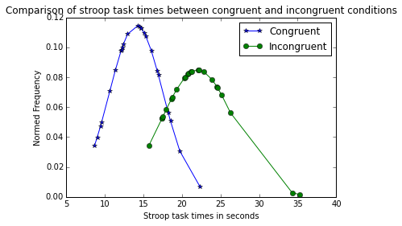

```
The figure shows that the data is normally distributed.
```

```python
# distribution of the sample data
# Reference [3]

%matplotlib inline
import numpy as np
import scipy.stats as stats
import pylab as pl

pl.figure()
con = sorted(dataFrame['Congruent'])
incon = sorted(dataFrame['Incongruent'])

fit = stats.norm.pdf(con, np.mean(con), np.std(con))
fit_incon = stats.norm.pdf(incon, np.mean(incon), np.std(incon))

pl.title('Comparison of stroop task times between congruent and incongruent conditions')
pl.xlabel('Stroop task times in seconds')
pl.ylabel('Normed Frequency')
pl.plot(con,fit,'-*',label='Congruent')
pl.plot(incon,fit_incon,'-o',label='Incongruent')
pl.legend()

pl.show()

print "The figure shows that the data is normally distributed.\n\n"
```

### 5. Now, perform the statistical test and report your results. What is your confidence level and your critical statistic value? Do you reject the null hypothesis or fail to reject it? Come to a conclusion in terms of the experiment task. Did the results match up with your expectations?

**5A. Perform the statistical test and report your results.**

```python
# Reference [4]
from scipy import stats
paired_sample = stats.ttest_rel(incon, con)
print "The t-statistic is %.3f and the p-value is %.3f.\n" % paired_sample
```

```
The t-statistic is 20.837 and the p-value is 0.000.
```

**5B. What is your confidence level and your critical statistic value?**

**Confidence level:** 95%

```python
n=len(diff)-1
print "\nDegree of freedom: %s"%n
print "\nt-critical value: +/- 2.069"
```

```
Degree of freedom: 23

t-critical value: +/- 2.069
```

**5C. Do you reject the null hypothesis or fail to reject it?**

Because $20.837>2.069$, that's $t-statistic > t-critical$, therefore, we reject the null hypothesis. That means, we accept the alternative hypothesis. In that case, we could conclude that there **HAS** significant difference between average stroop test times in seconds for congruent and incongruent conditions. Expecially, the stroop test times for incongruent condition is significantly longer than congruent one.

**5D. Did the results match up with your expectations?**

Yes.

### References

1. Student's T-test. Wiki: https://en.wikipedia.org/wiki/Student%27s_t-test
2. Python Pandas cheat sheet. http://nbviewer.ipython.org/github/pybokeh/ipython_notebooks/blob/master/pandas/PandasCheatSheet.ipynb#options
3. Plot Normal distribution with Matplotlib. http://stackoverflow.com/questions/20011494/plot-normal-distribution-with-matplotlib
4. scipy.stats.ttest_rel. http://docs.scipy.org/doc/scipy-0.15.1/reference/generated/scipy.stats.ttest_rel.html
5. Student's T Critical Values. https://people.richland.edu/james/lecture/m170/tbl-t.html
6. Evaluating mean confidence interval in Java and Python. http://www.ippatsuman.com/2014/08/10/evaluating-mean-confidence-interval-in-java-and-python/